# 2020 Election Analysis

Zhiyi Guo and Jianing Song

## Data

We will essentially start the anlaysis with two data sets. The first one is the election data, which is drawn from here. The data contains county-level election results. Note that this is not the final election results, as recounting are still taking place in many states.

The second dataset is the 2017 United States county-level census data, which is available here.

The following code load in these two data sets: election.raw and census.

## *Election data*

1. Report the dimension of *election.raw*.

```
## [1] 31167     5
```

The dimension of election.raw is 31167 rows and 5 columns.

Are there missing values in the data set?

```
## [1] 0
```

So there is no missing values in the election.raw data set.

Compute the total number of distinct values in state in *election.raw* to verify that the data contains all states and a federal district.

```
## [1] 51
```

The data contains all states and a federal district Washington D.C.

## *Census data*

2. Report the dimension of census.

```
## [1] 3220   37
```

Are there missing values in the data set?

```
## [1] 1
```

1 missing value.

Compute the total number of distinct values in county in census. Compare the values of total number of distinct county in census with that in election.raw. Comment on your findings.

```
## [1] 2825
```

```
## [1] 1955
```

The census data has fewer observations compared to the election.raw data.

## *Data wrangling*

3. Construct aggregated data sets from *election.raw* data: i.e.,
- Keep the county-level data as it is in *election.raw.*
- Create a state-level summary into a *election.state.*
- Create a federal-level summary into a *election.total.*
4. How many named presidential candidates were there in the 2020 election? Draw a bar chart of all votes received by each candidate. You can split this into multiple plots or may prefer to plot the results on a log scale. Either way, the results should be clear and legible! (For fun: spot Kanye West among the presidential candidates!)

There are total 38 presidential candidates in the 2020 election. Kanye West is among one of them.

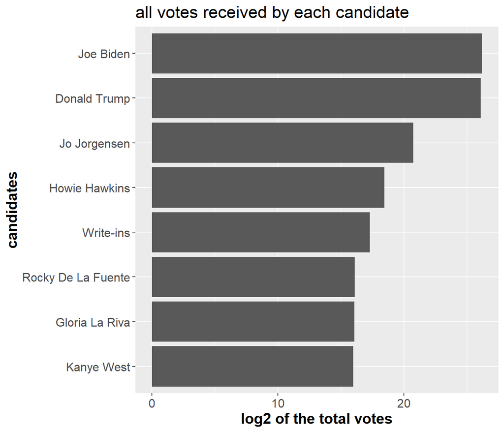

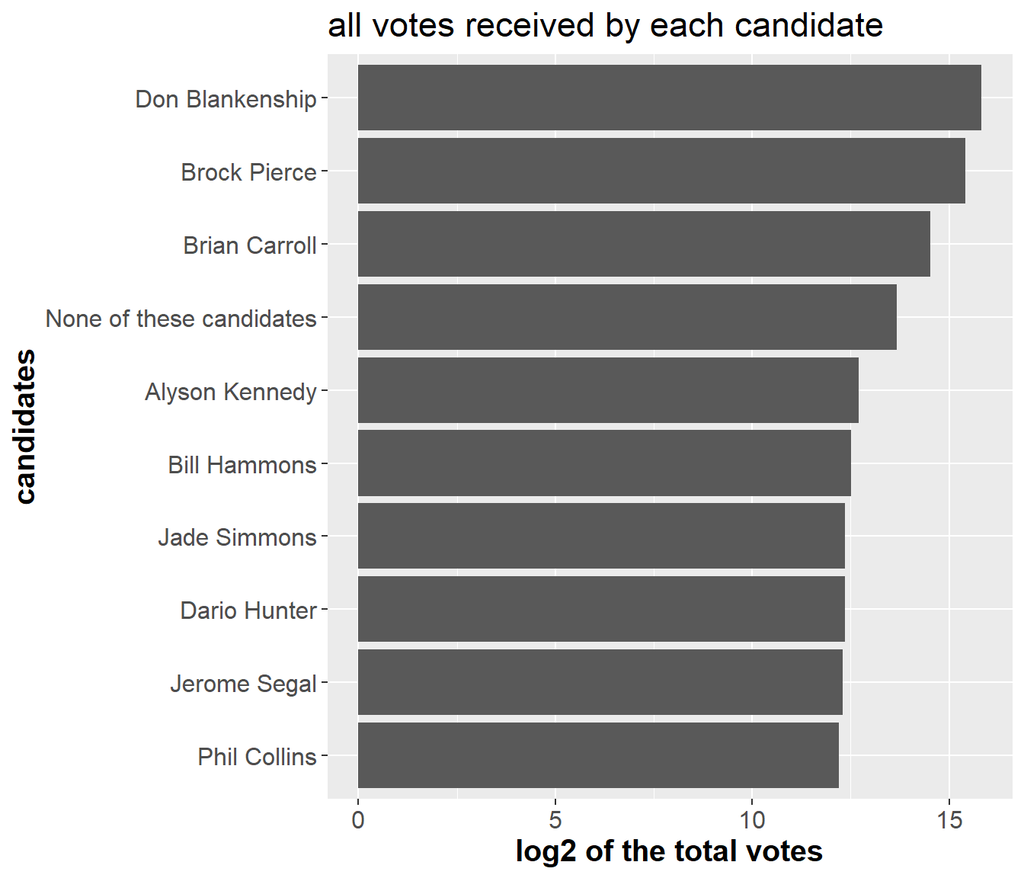

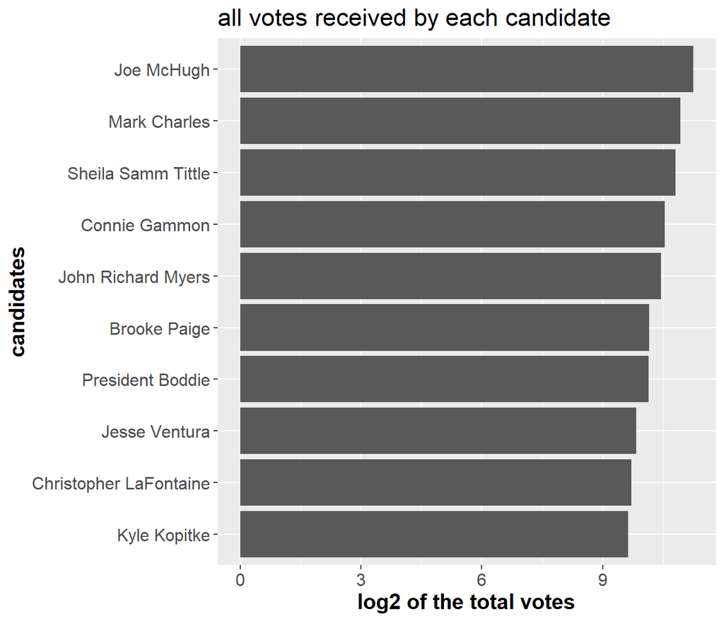

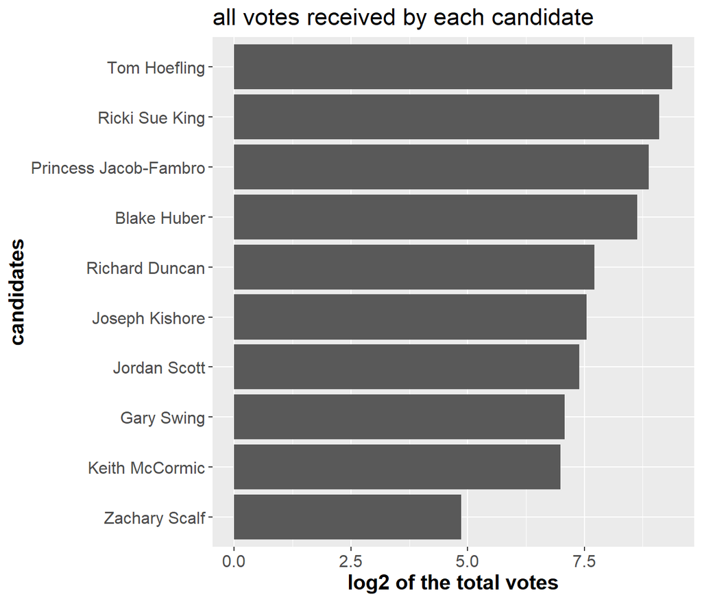

5. Create data sets *county.winner* and *state.winner* by taking the candidate with the highest proportion of votes in both county level and state level. Hint: to create *county.winner*, start with election.raw, group by county, compute total votes, and pct = votes/total as the proportion of votes. Then choose the highest row using top_n (variable *state.winner* is similar).

## *Visualization*

Visualization is crucial for gaining insight and intuition during data mining. We will map our data onto maps.

The R package *ggplot2* can be used to draw maps. Consider the following code.

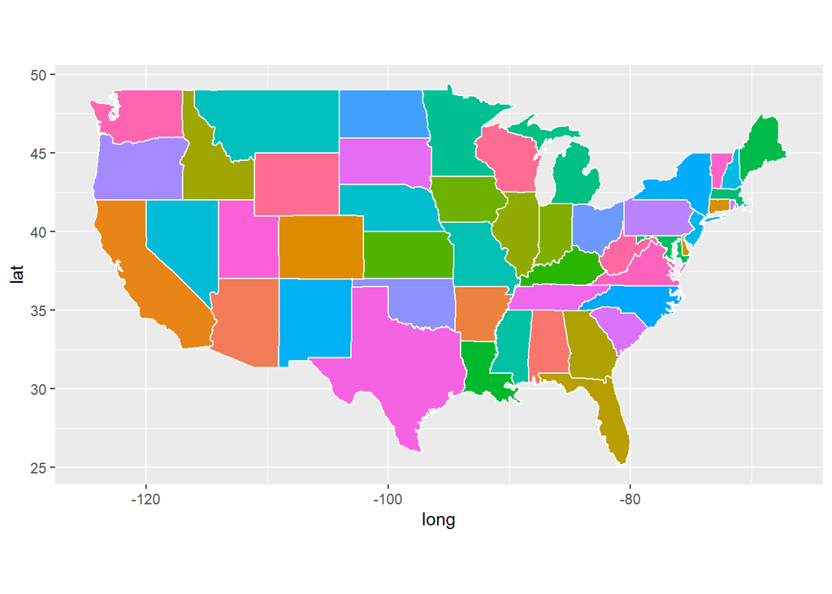

The variable states contain information to draw white polygons, and fill-colors are determined by region.

6. Use similar code to above to draw county-level map by creating counties = map_data(“county”). Color by county.

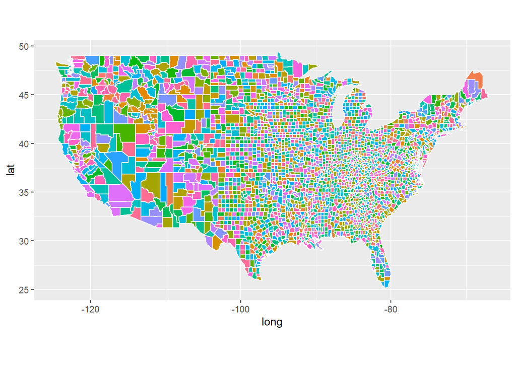

7. Now color the map by the winning candidate for each state. First, combine states variable and state.winner we created earlier using left_join(). Note that left_join() needs to match up values of states to join the tables. A call to left_join() takes all the values from the first table and looks for matches in the second table. If it finds a match, it adds the data from the second table; if not, it adds missing values:

Here, we’ll be combing the two data sets based on state name. However, the state names in states and state.winner can be in different formats: check them! Before using left_join(), use certain transform to make sure the state names in the two data sets: states (for map drawing) and state.winner (for coloring) are in the same formats. Then left_join(). Your figure will look similar to New York Times map.

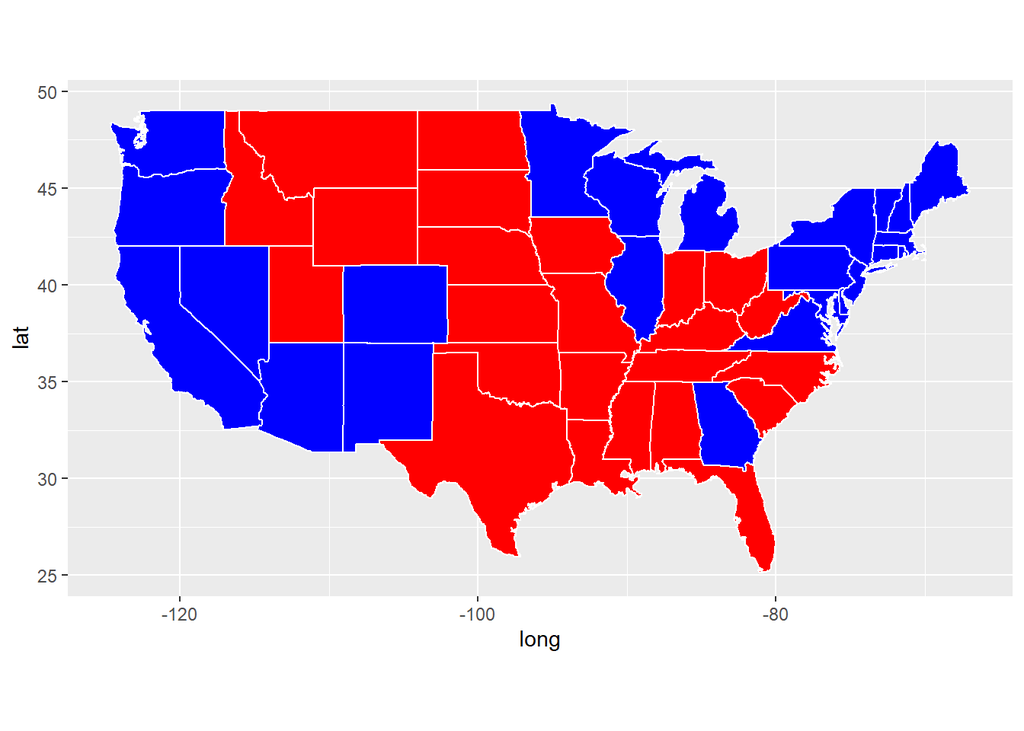

The red states are the states Trump wins, and the blue states are the states Biden wins.

8. Color the map of the state of California by the winning candidate for each county. Note that some county have not finished counting the votes, and thus do not have a winner. Leave these counties uncolored.

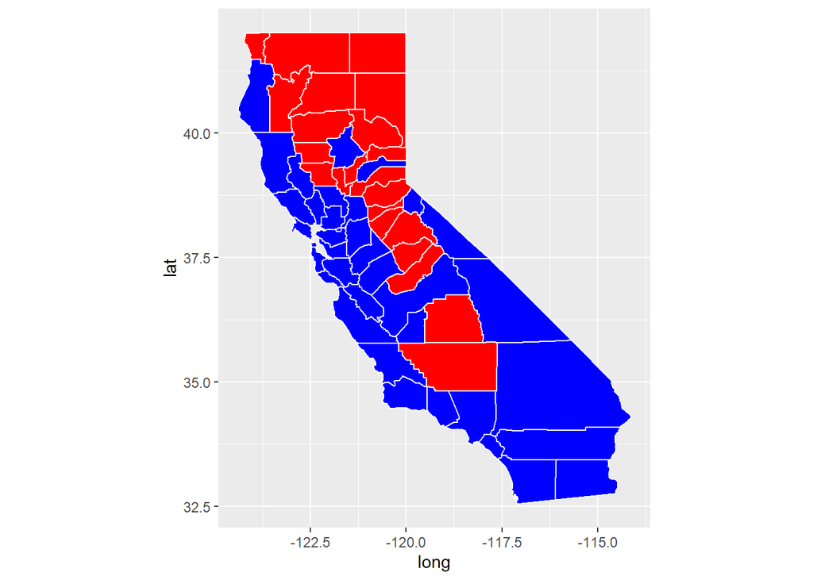

9. (Open-ended) Create a visualization of your choice using census data. Many exit polls noted that demographics played a big role in the election. Use this Washington Post article and this R graph gallery for ideas and inspiration.

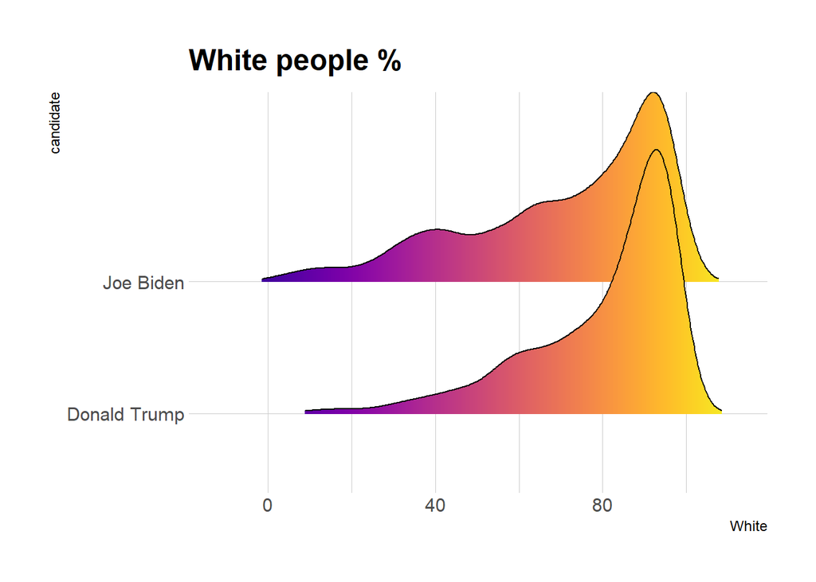

From this ridge plot, in the counties with more minorities, Joe Biden is more favored than Trump.

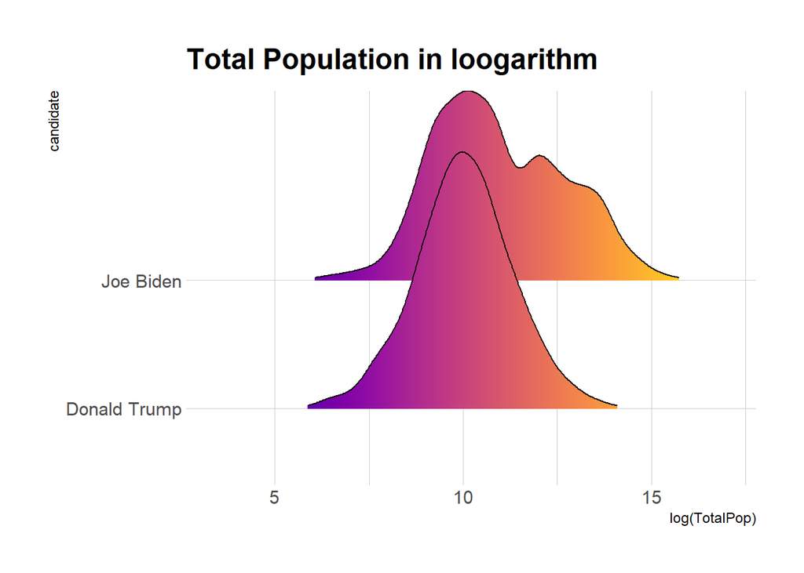

From this ridge plot, Joe Biden is more favored in the big cities with more population.

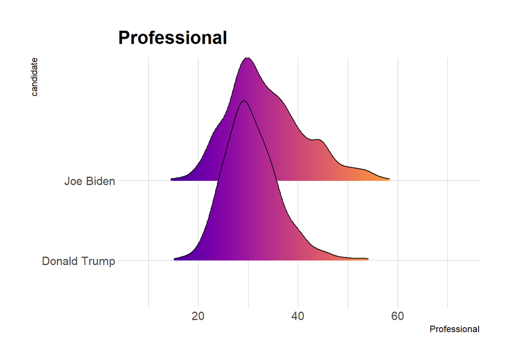

From this ridge plot, Joe Biden is more favored in the counties where there are more professional workers (lawyers, professors, doctors, etc).

10. The census data contains county-level census information. In this problem, we clean and aggregate the information as follows.
- Clean county-level census data census.clean: start with census, filter out any rows with missing values, convert {Men, Employed, VotingAgeCitizen} attributes to percentages, compute Minority attribute by combining {Hispanic, Black, Native, Asian, Pacific}, remove these variables after creating Minority, remove {IncomeErr, IncomePerCap, IncomePerCapErr, Walk, PublicWork, Construction}. Many columns are perfectly colineared, in which case one column should be deleted.
- Print the first 5 rows of census.clean:

```
## # A tibble: 5 x 26
##   CountyId State County TotalPop   Men White VotingAgeCitizen Income Poverty
##      <dbl> <chr> <chr>     <dbl> <dbl> <dbl>            <dbl>  <dbl>   <dbl>
## 1     1001 Alab~ Autau~    55036  48.9  75.4             74.5  55317    13.7
## 2     1003 Alab~ Baldw~   203360  48.9  83.1             76.4  52562    11.8
## 3     1005 Alab~ Barbo~    26201  53.3  45.7             77.4  33368    27.2
## 4     1007 Alab~ Bibb ~    22580  54.3  74.6             78.2  43404    15.2
## 5     1009 Alab~ Bloun~    57667  49.4  87.4             73.7  47412    15.6
## # ... with 17 more variables: ChildPoverty <dbl>, Professional <dbl>,
## #   Service <dbl>, Office <dbl>, Production <dbl>, Drive <dbl>, Carpool <dbl>,
## #   Transit <dbl>, OtherTransp <dbl>, WorkAtHome <dbl>, MeanCommute <dbl>,
## #   Employed <dbl>, PrivateWork <dbl>, SelfEmployed <dbl>, FamilyWork <dbl>,
## #   Unemployment <dbl>, Minority <dbl>
```

## *Dimensionality reduction*

11. Run PCA for the cleaned county level census data (with State and County excluded). Save the first two principle components PC1 and PC2 into a two-column data frame, call it pc.county. Discuss whether you chose to center and scale the features before running PCA and the reasons for your choice.

Center and scale are needed on the data before running PCA, because different columns has different mean and variation, some column such as population is very dispersed.

What are the three features with the largest absolute values of the first principal component?

Top 3 features of PC1

|  | PC1 | PC2 | features |
| --- | --- | --- | --- |
| Poverty | -0.3817489 | -0.0904984 | Poverty |
| ChildPoverty | -0.3810706 | -0.0508980 | ChildPoverty |
| Employed | 0.3510978 | 0.0374538 | Employed |

Which features have opposite signs and what does that mean about the correlation between these features?

Employed has a negative sign to Poverty and ChildPoverty, they have a negative correlation.

12. Determine the number of minimum number of PCs needed to capture 90% of the variance for the analysis. Plot proportion of variance explained (PVE) and cumulative PVE.

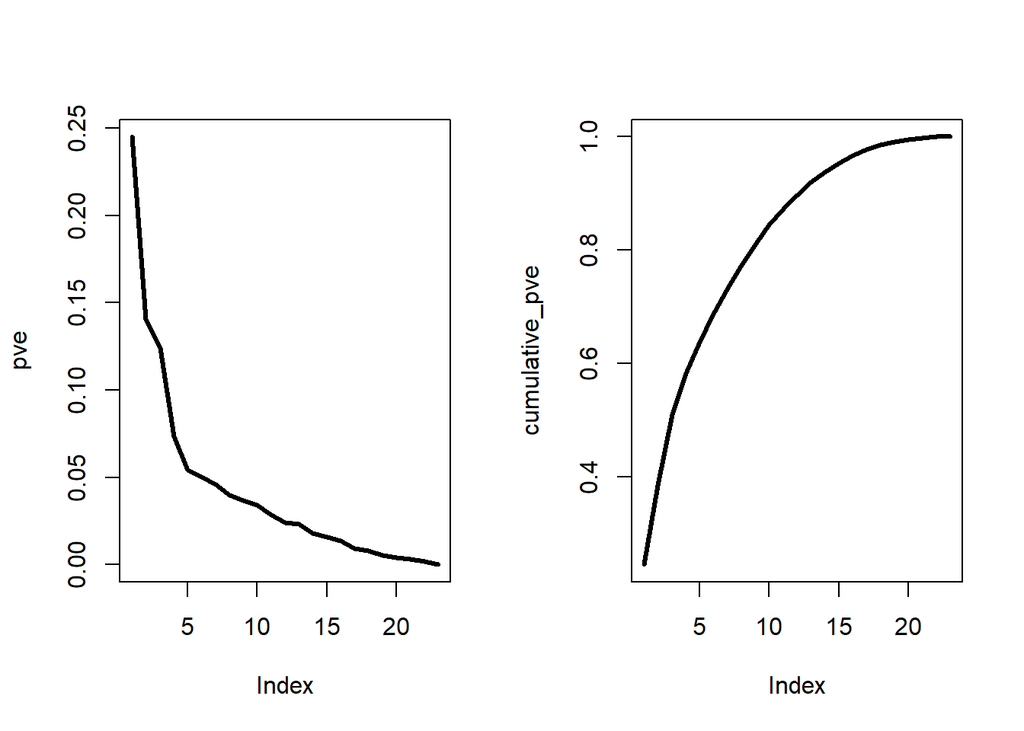

We need 13 PCs to capture 90% of the variance in our case.

## *Clustering*

13. With census.clean (with State and County excluded), perform hierarchical clustering with complete linkage. Cut the tree to partition the observations into 10 clusters.

cluster results

| 1 | 2 | 3 | 4 | 5 | 6 | 7 | 8 | 9 | 10 |
| --- | --- | --- | --- | --- | --- | --- | --- | --- | --- |
| 2924 | 191 | 6 | 5 | 31 | 1 | 17 | 6 | 34 | 4 |

Re-run the hierarchical clustering algorithm using the first 2 principal components from pc.county as inputs instead of the original features.

cluster results on pca

| 1 | 2 | 3 | 4 | 5 | 6 | 7 | 8 | 9 | 10 |
| --- | --- | --- | --- | --- | --- | --- | --- | --- | --- |
| 2064 | 404 | 252 | 76 | 209 | 20 | 163 | 1 | 17 | 13 |

Compare the results and comment on your observations. For both approaches investigate the cluster that contains Santa Barbara County. Which approach seemed to put Santa Barbara County in a more appropriate clusters? Comment on what you observe and discuss possible explanations for these observations.

When the cluster is used on the original data, the dimension of the cluster that Santa Barbara is in is:

```
## [1] 2924
```

The Santa Barbara is in the biggest cluster.

When the cluster is used on the PCA components, the dimension of the cluster that Santa Barbara is in is:

```
## [1] 163
```

It is in a cluster with only 163 counties. So the cluster method using the PCA is better than not using PCA. Because the cluster result is more subtle.

## *Classification*

We start considering supervised learning tasks now. The most interesting/important question to ask is: can we use census information in a county to predict the winner in that county?

In order to build classification models, we first need to combine county.winner and census.clean data. This seemingly straightforward task is harder than it sounds. For simplicity, the following code makes necessary changes to merge them into election.cl for classification.

14. Understand the code above. Why do we need to exclude the predictor party from election.cl?

Joe Biden is Democracy, Donald Trump is Republic. The predictor party is actually the same with the candidate.

- Using the following code, partition data into 80% training and 20% testing:

Use the following code to define 10 cross-validation folds:

Using the following error rate function. And the object records is used to record the classification performance of each method in the subsequent problems.

## *Decision tree*

15. Decision tree: train a decision tree by cv.tree(). Prune tree to minimize misclassification error. Be sure to use the folds from above for cross-validation.

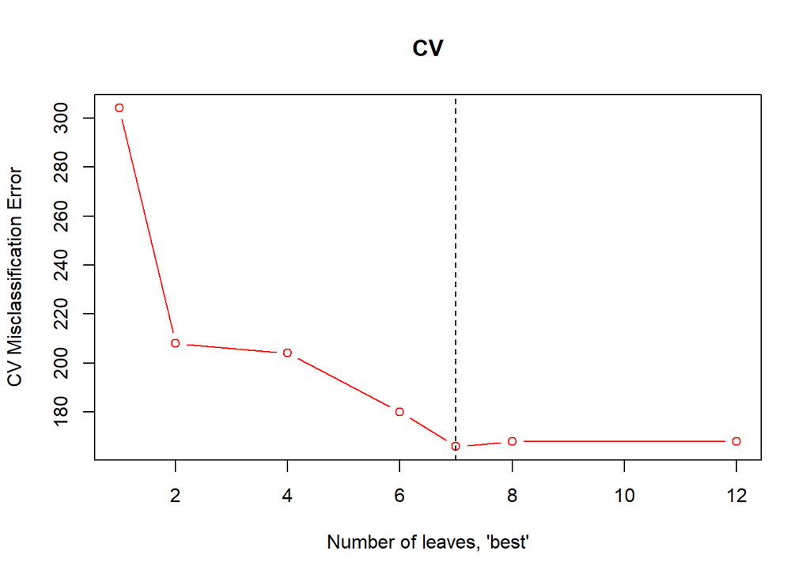

Visualize the trees before and after pruning.

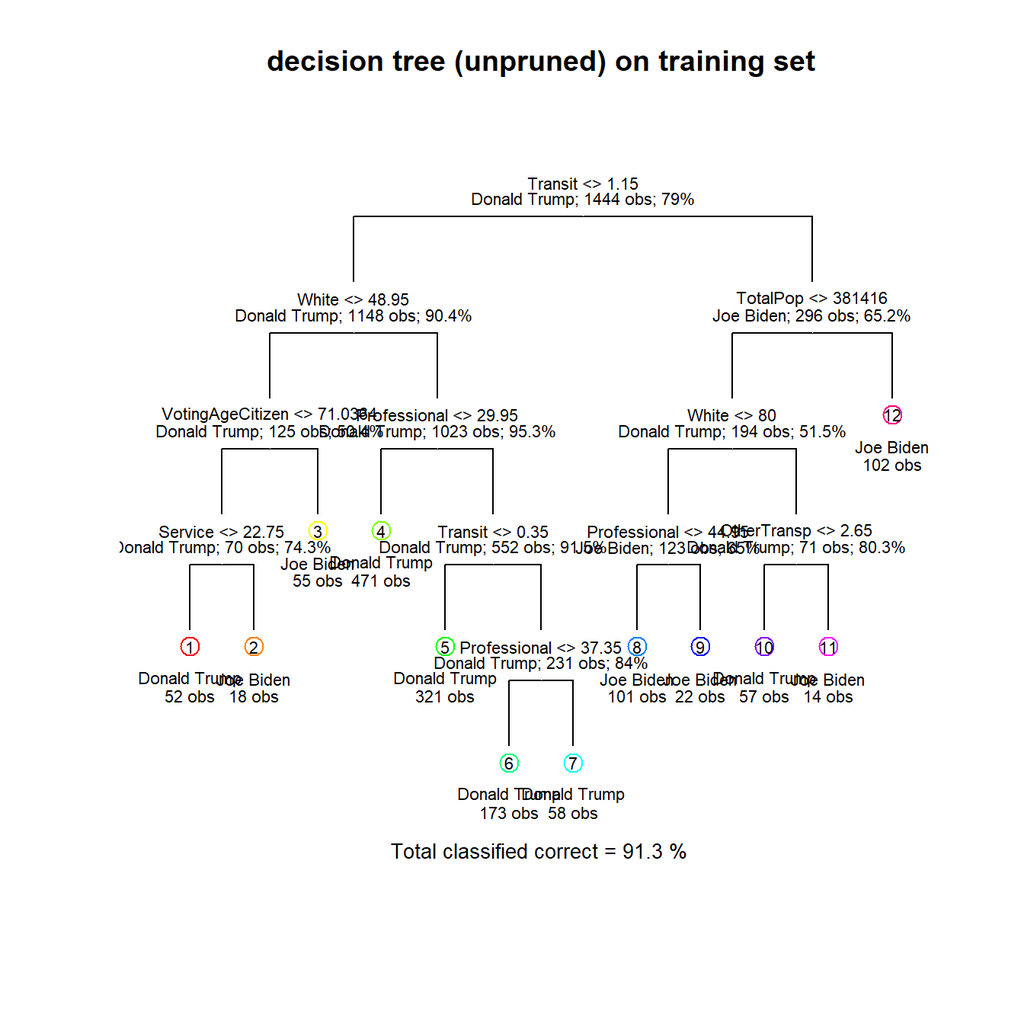

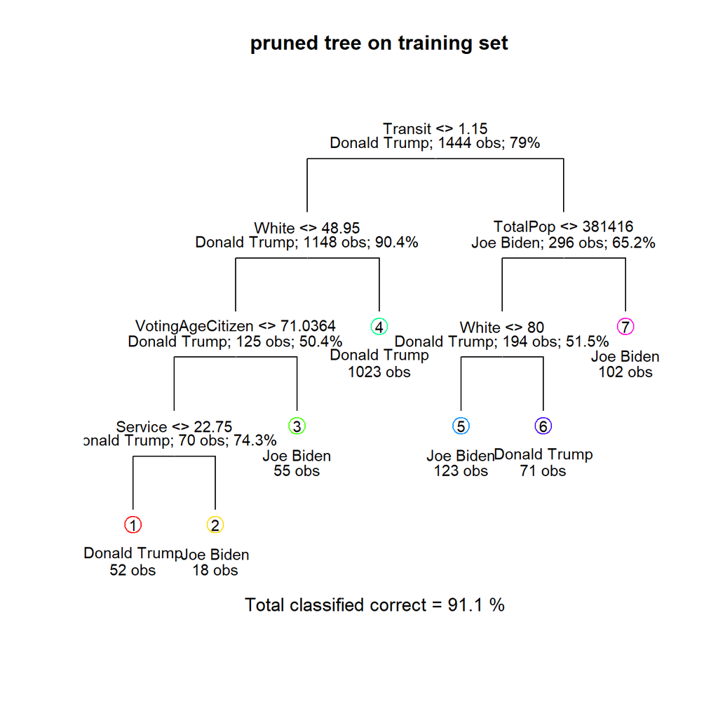

Save training and test errors to records object. Interpret and discuss the results of the decision tree analysis. Use this plot to tell a story about voting behavior.

The first variable separated in the cutted tree is transit, which may refers to whether the county is in cities or rural part. It shows that Trump is more favored in the county where the transit distance is far.

Also Trump is more favored in the county with more whites.

## *Logistic regression*

16. Run a logistic regression to predict the winning candidate in each county. Save training and test errors to records variable.

```
##
## Call:
## glm(formula = candidate ~ ., family = binomial, data = election.tr)
##
## Deviance Residuals:
##     Min       1Q   Median       3Q      Max
## -3.8427  -0.2544  -0.0993  -0.0222   3.3552
##
## Coefficients:
##                    Estimate Std. Error z value Pr(>|z|)
## (Intercept)      -2.027e+01  1.189e+01  -1.705  0.08822 .
## TotalPop          1.891e-06  7.630e-07   2.479  0.01319 *
## Men              -3.220e-03  6.133e-02  -0.053  0.95812
## White            -2.038e-01  8.562e-02  -2.380  0.01730 *
## VotingAgeCitizen  1.752e-01  3.130e-02   5.598 2.17e-08 ***
## Income           -1.335e-05  2.002e-05  -0.667  0.50492
## Poverty           1.683e-02  5.159e-02   0.326  0.74421
## ChildPoverty     -4.406e-04  3.200e-02  -0.014  0.98901
## Professional      3.130e-01  5.176e-02   6.047 1.48e-09 ***
## Service           3.265e-01  6.276e-02   5.202 1.97e-07 ***
## Office            1.587e-01  6.313e-02   2.514  0.01194 *
## Production        2.291e-01  5.368e-02   4.267 1.98e-05 ***
## Drive            -2.175e-01  5.685e-02  -3.827  0.00013 ***
## Carpool          -2.247e-01  7.541e-02  -2.980  0.00288 **
## Transit           5.601e-02  1.151e-01   0.487  0.62660
## OtherTransp       1.305e-01  1.167e-01   1.118  0.26370
## WorkAtHome       -1.312e-01  8.802e-02  -1.491  0.13595
## MeanCommute       3.580e-02  3.200e-02   1.119  0.26330
## Employed          2.442e-01  4.228e-02   5.776 7.65e-09 ***
## PrivateWork       7.147e-02  2.819e-02   2.535  0.01124 *
## SelfEmployed      1.955e-02  5.889e-02   0.332  0.73986
## FamilyWork       -3.708e-01  3.352e-01  -1.106  0.26854
## Unemployment      1.475e-01  5.167e-02   2.855  0.00431 **
## Minority         -5.898e-02  8.261e-02  -0.714  0.47525
## ---
## Signif. codes:  0 '***' 0.001 '**' 0.01 '*' 0.05 '.' 0.1 ' ' 1
##
## (Dispersion parameter for binomial family taken to be 1)
##
##     Null deviance: 1483.67  on 1443  degrees of freedom
## Residual deviance:  523.43  on 1420  degrees of freedom
## AIC: 571.43
##
## Number of Fisher Scoring iterations: 7
```

What are the significant variables?

Significant variables are TotalPop, White, VotingAgeCitizen, Professional, Service, Office, Production, Drive, Carpool, Employed, PrivateWork, Unemployment.

Are they consistent with what you saw in decision tree analysis? Interpret the meaning of a couple of the significant coefficients in terms of a unit change in the variables.

The total population and white is consistent with the decision tree. Transit is not significant in the logistic regression model.

Professional: 0.313, odd ratio $exp(0.313)=1.3675$.

1 unit increase of the Professional rate will multiply the ratio of probability Biden/Trump by 1.3675.

Drive: -0.2175, odd ratio $exp(-0.2175)=0.805$.

1 unit increase of the Drive will multiply the ratio of Biden/Trump by 0.805

17. You may notice that you get a warning glm.fit: fitted probabilities numerically 0 or 1 occurred. As we discussed in class, this is an indication that we have perfect separation (some linear combination of variables perfectly predicts the winner). This is usually a sign that we are overfitting. One way to control overfitting in logistic regression is through regularization.

Use the cv.glmnet function from the glmnet library to run a 10-fold cross validation and select the best regularization parameter for the logistic regression with LASSO penalty. Set lambda = seq(1, 50) * 1e-4 in cv.glmnet() function to set pre-defined candidate values for the tuning parameter.

What is the optimal value of lambda in cross validation?

The optimal value of lambda in cross validation is 8e-04.

What are the non-zero coefficients in the LASSO regression for the optimal value of lambda?

```
##      (Intercept)         TotalPop              Men            White
##    -2.409796e+01     1.988231e-06    -1.729674e-02    -1.337604e-01
## VotingAgeCitizen           Income          Poverty     ChildPoverty
##     1.709326e-01    -4.956570e-07     2.512126e-02     0.000000e+00
##     Professional          Service           Office       Production
##     2.656803e-01     2.807648e-01     1.273437e-01     1.849988e-01
##            Drive          Carpool          Transit      OtherTransp
##    -1.778751e-01    -1.736221e-01     7.601258e-02     1.410665e-01
##       WorkAtHome      MeanCommute         Employed      PrivateWork
##    -8.265186e-02     1.444156e-02     2.194428e-01     6.039737e-02
##     SelfEmployed       FamilyWork     Unemployment         Minority
##    -2.247953e-03    -3.411037e-01     1.413880e-01     0.000000e+00
```

Only ChildPoverty, Minority are forced to be 0.

How do they compare to the unpenalized logistic regression?

```
## [1] "The difference"
```

```
##      (Intercept)         TotalPop              Men            White
##    -3.829749e+00     9.701204e-08    -1.407643e-02     7.004853e-02
## VotingAgeCitizen           Income          Poverty     ChildPoverty
##    -4.262284e-03     1.285404e-05     8.286905e-03     4.405959e-04
##     Professional          Service           Office       Production
##    -4.733201e-02    -4.571869e-02    -3.136442e-02    -4.407153e-02
##            Drive          Carpool          Transit      OtherTransp
##     3.966613e-02     5.110666e-02     2.000119e-02     1.060257e-02
##       WorkAtHome      MeanCommute         Employed      PrivateWork
##     4.859101e-02    -2.135814e-02    -2.475968e-02    -1.107674e-02
##     SelfEmployed       FamilyWork     Unemployment         Minority
##    -2.180030e-02     2.972456e-02    -6.106708e-03     5.898260e-02
```

Save training and test errors to the records variable.

18. Compute ROC curves for the decision tree, logistic regression and LASSO logistic regression using predictions on the test data. Display them on the same plot. Based on your classification results, discuss the pros and cons of the various methods. Are the different classifiers more appropriate for answering different kinds of questions about the election?

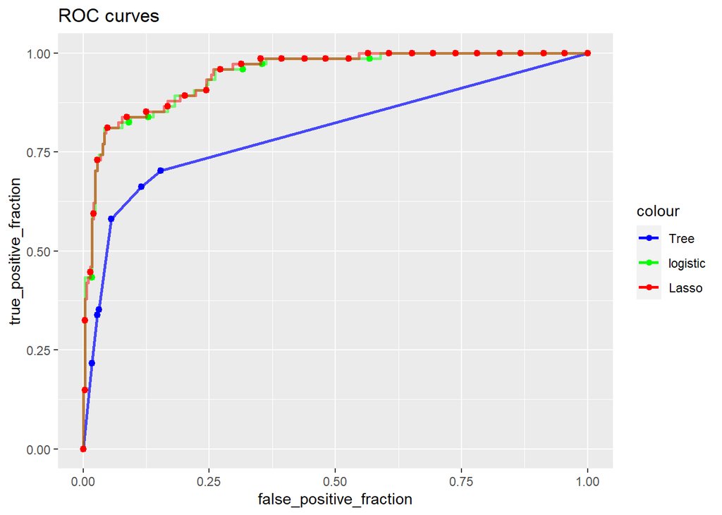

The logistic regression and the lasso logistic regression had similar performance in the ROC curve. The tree method had a much worse performance compared to the other two, because it’s a non-parametric method and the probability calculation is not as precise as the regression method. Overall, the prediction performance is not as bad as the ROC curve compared to the regression methods.

## *Taking it further*

19. Explore additional classification methods. Consider applying additional two classification methods from KNN, LDA, QDA, SVM, random forest, boosting, neural networks etc. (You may research and use methods beyond those covered in this course). How do these compare to the tree method, logistic regression, and the lasso logistic regression?

### KNN

Here we use 10 fold Cross validation to decide the best K for the KNN method.

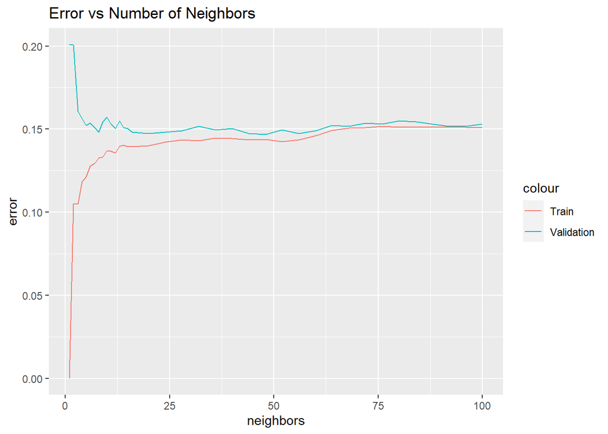

From the result the best knn parameter is near 48.

### SVM

```
##               svmpred
## data           Donald Trump Joe Biden
##   Donald Trump          283         4
##   Joe Biden              26        48
```

```
##               svmpred2
## data           Donald Trump Joe Biden
##   Donald Trump          281         6
##   Joe Biden              44        30
```

### Random forest

Now compare those 6 method performance on the train error and the test error:

```
##               train.error test.error
## tree           0.08933518 0.13019391
## logistic       0.06717452 0.08310249
## lasso          0.06994460 0.08033241
## KNN            0.14404432 0.19113573
## SVM            0.03878116 0.08310249
## Random Forest  0.00000000 0.28878116
```

The Lasso method has the least test error. The KNN method is much worse than the others except random forest. The random Forest method is clearly overfit.

Here we want to use principal components to create new (and lower dimensional) set of features with which to train a classification model. This sometimes improves classification performance. Compare classifiers trained on the original features with those trained on PCA features.

We will use only 5 PCs to fit those models.

- Decision tree on PCA

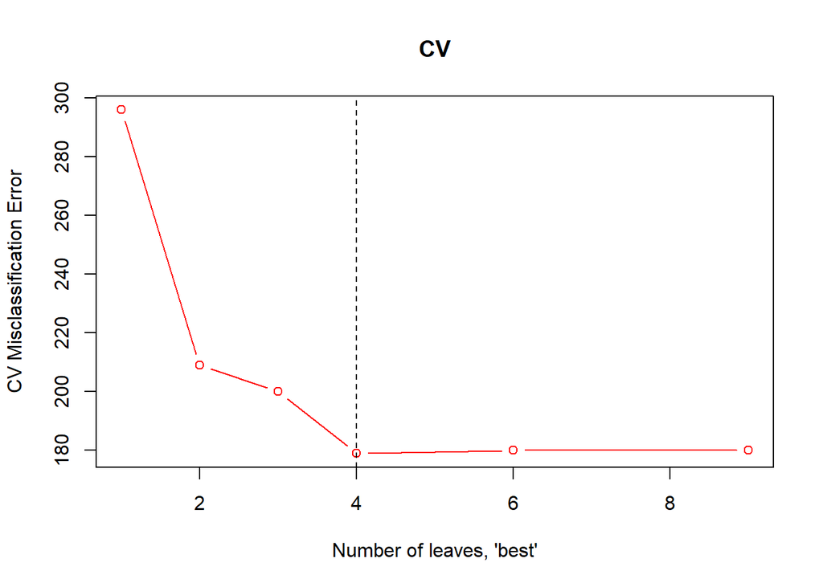

Visualize the trees before and after pruning.

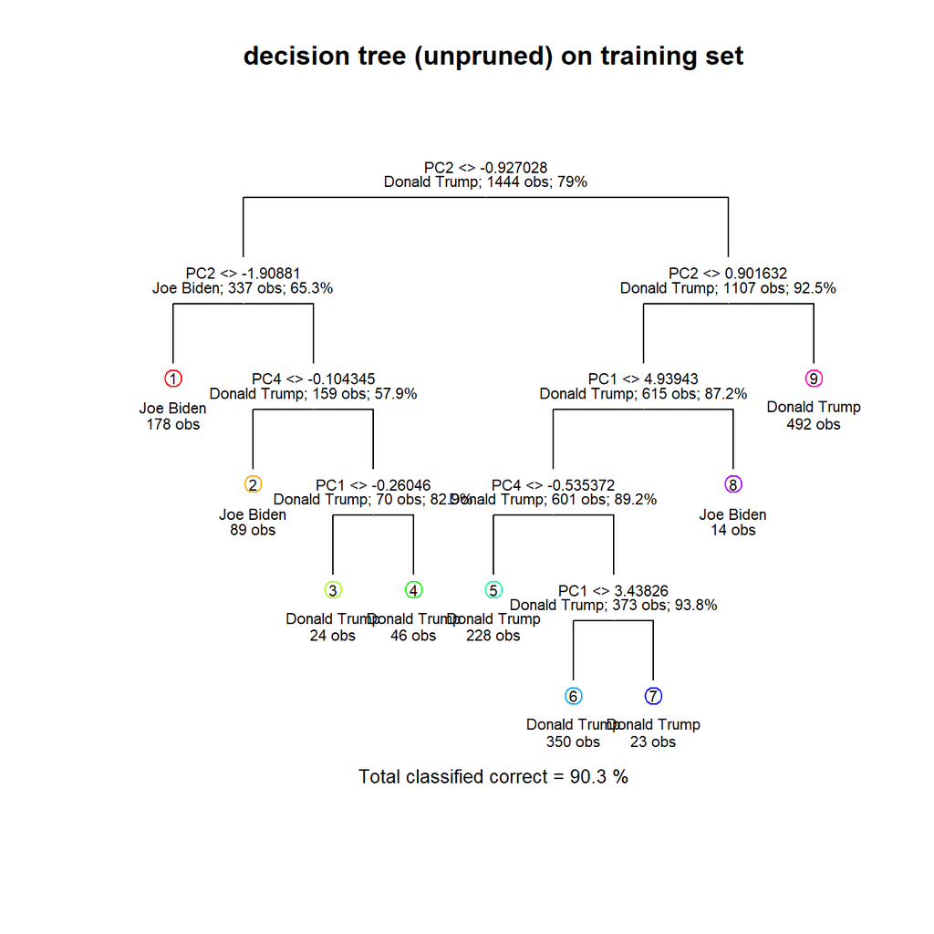

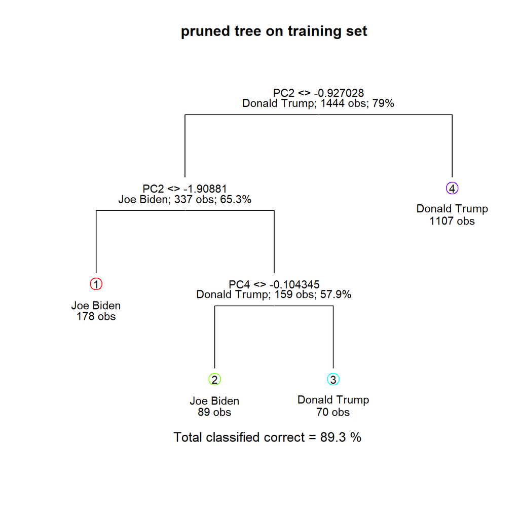

- Logistic and Lasso on PCA

```
##
## Call:
## glm(formula = candidate ~ ., family = binomial, data = election.pca.tr)
##
## Deviance Residuals:
##     Min       1Q   Median       3Q      Max
## -3.6405  -0.4300  -0.2137  -0.0880   3.0038
##
## Coefficients:
##             Estimate Std. Error z value Pr(>|z|)
## (Intercept) -2.20375    0.12222 -18.031  < 2e-16 ***
## PC1          0.09776    0.03819   2.560   0.0105 *
## PC2         -1.48160    0.08997 -16.468  < 2e-16 ***
## PC3          0.00635    0.06056   0.105   0.9165
## PC4         -0.59264    0.07999  -7.409 1.28e-13 ***
## PC5          0.26460    0.10351   2.556   0.0106 *
## ---
## Signif. codes:  0 '***' 0.001 '**' 0.01 '*' 0.05 '.' 0.1 ' ' 1
##
## (Dispersion parameter for binomial family taken to be 1)
##
##     Null deviance: 1483.67  on 1443  degrees of freedom
## Residual deviance:  798.22  on 1438  degrees of freedom
## AIC: 810.22
##
## Number of Fisher Scoring iterations: 6
```

- KNN on PCA

Here we use 10 fold Cross validation to decide the best K for the KNN method.

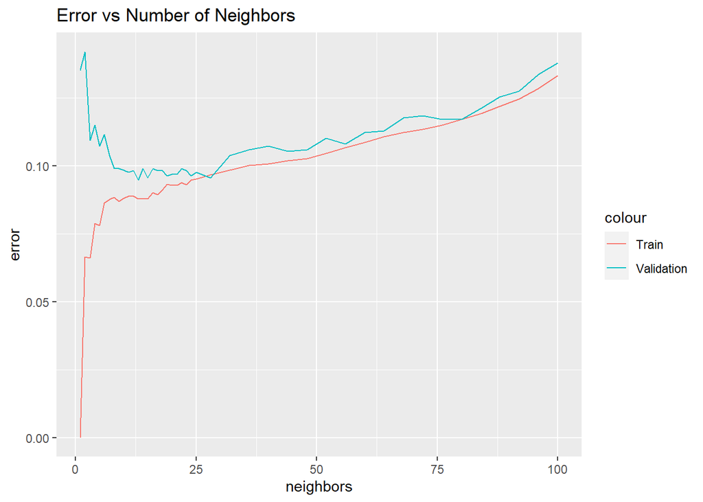

The best knn parameter is 13, not 48 anymore.

- SVM on PCA

```
##               svmpred
## data           Donald Trump Joe Biden
##   Donald Trump          279         8
##   Joe Biden              33        41
```

Now compare those 6 method performance on the train error and the test error:

```
##               train.error test.error
## tree           0.10664820  0.1246537
## logistic       0.11149584  0.1191136
## lasso          0.11149584  0.1191136
## KNN            0.09072022  0.1301939
## SVM            0.07894737  0.1135734
## Random Forest  0.00000000  0.2957064
```

Compare with the original without pca:

```
##               train.error test.error
## tree           0.08933518 0.13019391
## logistic       0.06717452 0.08310249
## lasso          0.06994460 0.08033241
## KNN            0.14404432 0.19113573
## SVM            0.03878116 0.08310249
## Random Forest  0.00000000 0.28878116
```

And their difference:

```
##               train.error   test.error
## tree           0.01731302 -0.005540166
## logistic       0.04432133  0.036011080
## lasso          0.04155125  0.038781163
## KNN           -0.05332410 -0.060941828
## SVM            0.04016620  0.030470914
## Random Forest  0.00000000  0.006925208
```

## Discussion

We have following conclusions from this project:

If we just compare the 6 methods on the dataset, the SVM method with radial kernel is the best, and the Lasso method has the smallest test error.

This result shows that on the oringinal dataset, the lasso regression method has the best generalization flexibility, and the SVM is the best performance method.

As lasso, logisitic and SVM are parametric methods, they have better performance than the deicision tree, and KNN method.

Random forest method has 0 train error and a 28.8% test error, which means it has seriously overfit problem so we should not use it.

On the original dataset, the KNN is much worse than the other methods on the performance.

It’s interesting to observe a huge improvement in the KNN method when apply PCA. Also the best parameter also changed from 48 to 13. The error vs parameter curve also changed. That result deserves future investigation.

## Appendix: R code

```r
knitr::opts_chunk$set(echo=FALSE, message=FALSE, warning=FALSE)
library(readr)
library(tidyverse)
library(dplyr)
library(ggplot2)
library(gridExtra)
library(grid)
library(tree)
library(maptree)
library(glmnet)
library(plotROC)
library(class)
library(randomForest)
library(reshape2)
## read data and convert candidate names and party names from string to factor
election.raw <- read_csv("candidates_county.csv", col_names = TRUE) %>%
  mutate(candidate = as.factor(candidate), party = as.factor(party))

## remove the word "County" from the county names
words.to.remove = c("County")
remove.words <- function(str, words.to.remove){
  sapply(str, function(str){
    x <- unlist(strsplit(str, " "))
    x <- x[!x %in% words.to.remove]
    return(paste(x, collapse = " "))
  }, simplify = "array", USE.NAMES = FALSE)
}
election.raw$county <- remove.words(election.raw$county, words.to.remove)

## read census data
census <- read_csv("census_county.csv")
#1.dimension
dim(election.raw)
sum(is.na(election.raw))
length(unique(election.raw$state))
dim(census)

sum(is.na(census))

length(unique(election.raw$county))
length(unique(census$County))
election.total = election.raw %>%
   group_by(candidate,party) %>%
   dplyr::summarise(votes = sum(votes))
election.state = election.raw %>%
   group_by(state,candidate,party) %>%
   dplyr::summarise(votes = sum(votes))

df = arrange(election.total,votes)
df$votes.log2 = log2(df$votes)

p1 = ggplot(df[1:10,], aes(x = reorder(candidate, votes.log2, sum),
    y = votes.log2)) +
  geom_col() +
  labs( x = "candidates",
        title ="all votes received by each candidate",
        y = "log2 of the total votes") +
  theme(axis.text=element_text(size=12),
        axis.title=element_text(size=15,face="bold"),
        plot.title = element_text(size=17)) +
  coord_flip()

p2 = ggplot(df[11:20,], aes(x = reorder(candidate, votes.log2, sum),
                            y = votes.log2)) +
  geom_col() +
  labs( x = "candidates",
        title ="all votes received by each candidate",
        y = "log2 of the total votes")+
  theme(axis.text=element_text(size=12),
        axis.title=element_text(size=15,face="bold"),
        plot.title = element_text(size=17))+
  coord_flip()
p3 = ggplot(df[21:30,], aes(x = reorder(candidate, votes.log2, sum), y = votes.log2)) +
  geom_col() +
  labs( x = "candidates",
        title ="all votes received by each candidate",
        y = "log2 of the total votes") +
  theme(axis.text=element_text(size=12),
        axis.title=element_text(size=15,face="bold"),
        plot.title = element_text(size=17)) +
  coord_flip()
p4 = ggplot(df[31:38,],
            aes(x = reorder(candidate, votes.log2, sum), y = votes.log2)) +
  geom_col() +
  labs( x = "candidates",
        title ="all votes received by each candidate",
        y = "log2 of the total votes")+
  theme(axis.text=element_text(size=12),
        axis.title=element_text(size=15,face="bold"),
        plot.title = element_text(size=17))+
  coord_flip()

p4
p3
p2
p1
county_winner = election.raw %>%
  group_by(county) %>%
  mutate(total=sum(votes), pct=votes/total) %>%
  top_n(1)

state_winner = election.state %>%
  group_by(state) %>%
  mutate(total=sum(votes), pct=votes/total) %>%
  top_n(1)
states <- map_data("state")

ggplot(data = states) +
  geom_polygon(aes(x = long, y = lat, fill = region, group = group),
               color = "white") +
  coord_fixed(1.3) +
  guides(fill=FALSE)  # color legend is unnecessary and takes too long
counties = map_data("county")
ggplot(data = counties) +
  geom_polygon(aes(x = long, y = lat,
   fill = subregion, group = group), color = "white") +
  coord_fixed(1.3) +
  guides(fill= FALSE)
states = states %>%
  mutate(state=
    state.name[match(states$region,
    tolower(state.name))])


ggplot(data = left_join(states, state_winner,
    by="state")) +
  geom_polygon(aes(x = long, y = lat,
        fill = candidate, group = group),
        color = "white") +
  scale_fill_manual(values=c("red", "blue"))+
  coord_fixed(1.3) +
  guides(fill= FALSE)

counties <- map_data("county")
ca_county <- subset(counties, region == "california")
ca_county$county = ca_county$subregion
county_winner$county = tolower(county_winner$county)

ggplot(data = left_join(ca_county,
  county_winner, by = "county")) +
  geom_polygon(aes(x = long, y = lat,
        fill = candidate, group = group),
        color = "white") +
  scale_fill_manual(values=c("red", "blue"))+
  coord_fixed(1.3) +
  guides(fill= FALSE)
census.clean = na.omit(census) %>% mutate(Men = Men/TotalPop*100,
  Employed = Employed/TotalPop*100,
  VotingAgeCitizen = VotingAgeCitizen/TotalPop*100,
  Minority = Hispanic+Black+Native+Asian+Pacific) %>%
  select(-Women, -Hispanic, -Native,
         -Black, -Asian, -Pacific, -Construction,
         -Walk, -PublicWork,-IncomePerCapErr,
         -IncomeErr, -IncomePerCap)

census.clean$county = tolower(census.clean$County)
county_winner$county = paste0(tolower(county_winner$county)," county")
library(ggridges)
library(ggplot2)
library(viridis)
library(hrbrthemes)



df = left_join(census.clean, county_winner, by = "county")%>%
  filter(candidate == "Joe Biden" | candidate == "Donald Trump")%>%
  group_by(candidate)
df$candidate = droplevels(df$candidate)

# Plot
ggplot(df, aes(x = White, y = candidate, fill = ..x..)) +
  geom_density_ridges_gradient(scale =2, rel_min_height = 0.01) +
  scale_fill_viridis(name = "White", option = "C") +
  labs(title = 'White people %') +
  theme_ipsum() +
    theme(
      legend.position="none",
      panel.spacing = unit(0.1, "lines"),
      strip.text.x = element_text(size = 8)
    )
# Plot
ggplot(df, aes(x = log(TotalPop), y = candidate, fill = ..x..)) +
  geom_density_ridges_gradient(scale =2, rel_min_height = 0.01) +
  scale_fill_viridis(name = "TotalPop", option = "C") +
  labs(title = 'Total Population in loogarithm') +
  theme_ipsum() +
    theme(
      legend.position="none",
      panel.spacing = unit(0.1, "lines"),
      strip.text.x = element_text(size = 8)
    )
# Plot
ggplot(df, aes(x = Professional, y = candidate, fill = ..x..)) +
  geom_density_ridges_gradient(scale =2, rel_min_height = 0.01) +
  scale_fill_viridis(name = "Professional", option = "C") +
  labs(title = 'Professional') +
  theme_ipsum() +
    theme(
      legend.position="none",
      panel.spacing = unit(0.1, "lines"),
      strip.text.x = element_text(size = 8)
    )
census.clean = na.omit(census) %>%
  mutate(Men = Men/TotalPop*100,
  Employed = Employed/TotalPop*100,
  VotingAgeCitizen = VotingAgeCitizen/TotalPop*100,
  Minority = Hispanic+Black+Native+Asian+Pacific) %>%
  select(-Women, -Hispanic, -Native,
         -Black, -Asian, -Pacific, -Construction,
         -Walk, -PublicWork,-IncomePerCapErr,
         -IncomeErr, -IncomePerCap)
head(census.clean,5)
pc.county = prcomp(census.clean[4:26], scale=TRUE, center = TRUE)
ct.pc = data.frame(pc.county$rotation[,1:2],
    features = rownames(pc.county$rotation))
knitr::kable(ct.pc %>% top_n(3,abs(PC1)),caption = "Top 3 features of PC1")
pc.var=(pc.county$sdev)^2
pve = pc.var/sum(pc.var)
cumulative_pve = cumsum(pve)
par(mfrow=c(1, 2))
plot(pve, type="l", lwd=3)
plot(cumulative_pve, type="l", lwd=3)
census.cluster = hclust(dist(scale(census.clean[4:26]), method="euclidean"), method="complete")
census.cluster.res = cutree(census.cluster, k=10)
knitr::kable(t(table(census.cluster.res)),caption = "cluster results")
census.cluster.pca = hclust(dist(scale(pc.county$x[,1:2]), method="euclidean"), method="complete")
census.cluster.pca.res = cutree(census.cluster.pca, k=10)
knitr::kable(t(table(census.cluster.pca.res)),caption = "cluster results on pca")
t1 = census.cluster.res[which(census$County == "Santa Barbara County")]
t2 = census.cluster.pca.res[which(census$County == "Santa Barbara County")]
cluster1 = census %>% drop_na() %>% mutate(Cluster=census.cluster.res) %>% filter(Cluster == t1)
dim(cluster1)[1]
cluster2 = census %>% drop_na() %>% mutate(Cluster=census.cluster.pca.res) %>% filter(Cluster == t2)
dim(cluster2)[1]
county_winner = election.raw %>%
  group_by(county) %>%
  mutate(total=sum(votes), pct=votes/total) %>%
  top_n(1)
```

```r
state_winner = election.state %>%
  group_by(state) %>%
  mutate(total=sum(votes), pct=votes/total) %>%
  top_n(1)
# we move all state and county names into lower-case
county.winner = county_winner
tmpwinner <- county.winner %>% ungroup %>%
  mutate_at(vars(state, county), tolower)

# we move all state and county names into lower-case
# we further remove suffixes of "county" and "parish"
tmpcensus <- census.clean %>% mutate_at(vars(State, County), tolower) %>%
  mutate(County = gsub(" county|  parish", "", County))

# we join the two datasets
election.cl <- tmpwinner %>%
  left_join(tmpcensus, by = c("state"="State", "county"="County")) %>%
  na.omit

# drop levels of county winners if you haven't done so in previous parts
election.cl$candidate <- droplevels(election.cl$candidate)

## save meta information
election.meta <- election.cl %>% select(c(county, party, CountyId, state, votes, pct, total))

## save predictors and class labels
election.cl = election.cl %>% select(-c(county, party, CountyId, state, votes, pct, total))

set.seed(10)
n <- nrow(election.cl)
idx.tr <- sample.int(n, 0.8*n)
election.tr <- election.cl[idx.tr, ]
election.te <- election.cl[-idx.tr, ]
set.seed(20)
nfold <- 10
folds <- sample(cut(1:nrow(election.tr), breaks=nfold, labels=FALSE))
calc_error_rate = function(predicted.value, true.value){
return(mean(true.value!=predicted.value))
}
records = matrix(NA, nrow=6, ncol=2)
colnames(records) = c("train.error","test.error")
rownames(records) = c("tree","logistic","lasso","KNN","SVM","Random Forest")

#get the X and Y
train.X = election.tr %>% select(-candidate)
train.Y = election.tr %>% select(candidate)
test.X = election.te %>% select(-candidate)
test.Y = election.te %>% select(candidate)
tree.all = tree(candidate~.,election.tr)
cvtree = cv.tree(tree.all, rand=folds,
                 FUN=prune.misclass)

best.cv = min(cvtree$size[which(cvtree$dev==min(cvtree$dev))])

plot(cvtree$size , cvtree$dev, type="b",
xlab = "Number of leaves, \'best\'", ylab = "CV Misclassification Error",
col = "red", main="CV")
abline(v=best.cv, lty=2)
draw.tree(tree.all, nodeinfo=TRUE, cex = 0.7)
title("decision tree (unpruned) on training set", cex = 0.7)

prune.tree = prune.misclass(tree.all, best=best.cv)
# Plot pruned tree
draw.tree(prune.tree, nodeinfo=TRUE, cex = 0.9)
title("pruned tree on training set")

train.error.tree =
  calc_error_rate(predict(prune.tree, train.X, type="class"),
                  train.Y$candidate)

test.error.tree =
  calc_error_rate(predict(prune.tree, test.X, type="class"),
                  test.Y$candidate)
records[1,1] = train.error.tree
records[1,2] = test.error.tree
glm.fit = glm(candidate~., data = election.tr, family = binomial)
summary(glm.fit)
logistic.train.prob = predict(glm.fit, train.X, type="response")
logistic.train.pred = rep("Donald Trump",
  length(train.Y$candidate))
logistic.train.pred[logistic.train.prob > 0.5]="Joe Biden"

train.error.logistic =
  calc_error_rate(logistic.train.pred, train.Y$candidate)
logistic.test.prob = predict(glm.fit, test.X, type="response")
logistic.test.pred = rep("Donald Trump",
  length(test.Y$candidate))
logistic.test.pred[logistic.test.prob > 0.5]="Joe Biden"
test.error.logistic = calc_error_rate(logistic.test.pred, test.Y$candidate)
records[2,1] = train.error.logistic
records[2,2] = test.error.logistic

lasso.fit <-
  cv.glmnet(x = as.matrix(train.X),
            y = droplevels(train.Y$candidate),
            type.measure="auc",
            family = "binomial",alpha = 1,
            lambda = seq(1, 50) * 1e-4, foldid = folds)
res = as.matrix(coef.relaxed(lasso.fit$glmnet.fit))[,43]
res
print("The difference")
res-glm.fit$coefficients
invlogit = function(t){
  return(exp(t)/(1+exp(t)))
}

X = as.matrix(train.X)
X = cbind(rep(1,length(X[,1])),X)

lasso.train.prob = sapply(X %*% res, invlogit)
lasso.train.pred = rep("Donald Trump", length(train.Y$candidate))

lasso.train.pred[lasso.train.prob > 0.5]="Joe Biden"
train.error.lasso = calc_error_rate(lasso.train.pred, train.Y$candidate)


X = as.matrix(test.X)
X = cbind(rep(1,length(X[,1])),X)
lasso.test.prob = sapply(X %*% res, invlogit)
lasso.test.pred = rep("Donald Trump", length(test.Y$candidate))
lasso.test.pred[lasso.test.prob > 0.5]="Joe Biden"
test.error.lasso = calc_error_rate(lasso.test.pred, test.Y$candidate)

records[3,1] = train.error.lasso
records[3,2] = test.error.lasso
df =
  data.frame(prediction.tree = predict(prune.tree, test.X, type="vector")[,2],
             prediction.logistic = logistic.test.prob,
             prediction.Lasso = lasso.test.prob,
             labels = droplevels(test.Y$candidate))

ggplot(df,aes(d = labels))+
  geom_roc(aes(m = prediction.tree,d = labels,color = "blue"),n.cuts=30,labels=FALSE,linealpha=0.7) +
  geom_roc(aes(m = prediction.logistic,d = labels,color = "green"),n.cuts=30,labels=FALSE,linealpha=0.5)+
  geom_roc(aes(m = prediction.Lasso,d = labels,color = "red"),n.cuts=30,labels=FALSE,linealpha=0.5) +
  ggtitle("ROC curves") + scale_colour_manual(
  values = c("blue","green","red"),
  labels = c("Tree","logistic", "Lasso")
)

# do.chunk() for k-fold Cross-validation
do.chunk <- function(chunkid, folddef, Xdat, Ydat, ...){
  # Function arguments

  train = (folddef!=chunkid) # Get training index

  Xtr = Xdat[train,] # Get training set by the above index
  Ytr = Ydat[train] # Get true labels in training set
  Xvl = Xdat[!train,] # Get validation set
  Yvl = Ydat[!train] # Get true labels in validation set

  predYtr = knn(train=Xtr, test=Xtr, cl=Ytr, ...) # Predict training labels
  predYvl = knn(train=Xtr, test=Xvl, cl=Ytr, ...) # Predict validation labels

  data.frame(fold = chunkid, # k folds
  train.error = mean(predYtr != Ytr), # Training error for each fold
  val.error = mean(predYvl != Yvl)) # Validation error for each fold
}

# Set error.folds (a vector) to save validation errors in future
error.folds = NULL
# Give possible number of nearest neighbours to be considered
allK = c(1:15,seq(16,100,4))
# Set seed since do.chunk() contains a random component induced by knn()
set.seed(888)
# Loop through different number of neighbors
for (j in allK){
tmp = plyr::ldply(1:nfold, do.chunk, # Apply do.chunk() function to each fold
folddef=folds, Xdat=train.X, Ydat=train.Y$candidate, k=j)
# Necessary arguments to be passed into do.chunk
tmp$neighbors = j # Keep track of each value of neighors
error.folds = rbind(error.folds, tmp) # combine results
}
```

```r
# Transform the format of error.folds for further convenience
errors = melt(error.folds, id.vars=c('fold', 'neighbors'), value.name='error')
# Choose the number of neighbors which minimizes validation error

val.error.means = errors %>%
  # Select all rows of validation errors
  filter(variable=='val.error') %>%
  # Group the selected data frame by neighbors
  group_by(neighbors, variable) %>%
  # Calculate CV error rate for each k
  summarise_each(funs(mean), error) %>%
  # Remove existing group
  ungroup()
min.error <- val.error.means %>%
  filter(error==min(error))
bestk <- max(min.error$neighbors)
# calculating training errors at each k
# (by taking mean of each cv result)

train.error.means <- errors %>%
  filter(variable=="train.error") %>%
  group_by(neighbors) %>%
  summarise_at(vars(error),funs(mean))

# plotting
ggplot(train.error.means) +
  geom_line(aes(neighbors,error,color="Train")) +
  geom_line(data  = val.error.means,
            aes(neighbors,error,color="Validation")) +
  ggtitle("Error vs Number of Neighbors")

# training errors
pred.knn.train <- knn(train=train.X, test=train.X, cl=train.Y$candidate, k=bestk)
train.error <- calc_error_rate(pred.knn.train, train.Y$candidate)
# test errors
pred.knn.test <- knn(train=train.X, test=test.X, cl=train.Y$candidate, k=bestk)
test.error <- calc_error_rate(pred.knn.test, test.Y$candidate)
# adding to records
records[4,1] <- train.error
records[4,2] <- test.error
library(e1071)
svmfit = svm(candidate ~ .,data = election.tr,kernel ="radial",cost = 1)
svmfit2 = svm(candidate ~ .,data = election.tr,kernel ="polynomial",cost = 1)
svmpred = predict(svmfit,newdata =test.X)
table(data = test.Y$candidate,svmpred)

svmpred2 = predict(svmfit2,newdata =test.X)
table(data = test.Y$candidate,svmpred2)
# training errors
pred.svm.train <-  predict(svmfit,newdata =train.X)
train.error <- calc_error_rate(pred.svm.train, train.Y$candidate)
# test errors
pred.svm.test <- predict(svmfit,newdata =test.X)
test.error <- calc_error_rate(pred.svm.test, test.Y$candidate)
# adding to records
records[5,1] <- train.error
records[5,2] <- test.error
rf.fit <- randomForest(formula =
  droplevels(as.factor(candidate)) ~.,data = election.tr)

# training errors
forest.predict.train <- predict(rf.fit, train.X)
label = droplevels(train.Y$candidate)
train.error <- calc_error_rate(forest.predict.train, label)
# test errors
forest.predict.test <- predict(rf.fit, test.X)
test.error <- calc_error_rate(forest.predict.test, label)
records[6,1] <- train.error
records[6,2] <- test.error
records
election.pca.fit = election.cl %>%
  select(-c(candidate)) %>%
  prcomp(scale=TRUE, center = TRUE)
election.pca.df = data.frame(election.pca.fit$x[,1:5])

# We will use only 5 PCs to fit those models.

election.pca.df$candidate = election.cl$candidate

election.pca.tr<- election.pca.df[idx.tr, ]
election.pca.te <- election.pca.df[-idx.tr, ]

train.X = election.pca.tr %>% select(-candidate)
train.Y = election.pca.tr %>% select(candidate)
test.X = election.pca.te %>% select(-candidate)
test.Y = election.pca.te %>% select(candidate)

record.pca = matrix(NA, nrow=6, ncol=2)
colnames(record.pca) = c("train.error","test.error")
rownames(record.pca) = c("tree","logistic","lasso","KNN","SVM","Random Forest")
tree.all = tree(candidate~.,election.pca.tr)
cvtree = cv.tree(tree.all, rand=folds,
                 FUN=prune.misclass)

best.cv = min(cvtree$size[which(cvtree$dev==min(cvtree$dev))])

plot(cvtree$size , cvtree$dev, type="b",
xlab = "Number of leaves, \'best\'", ylab = "CV Misclassification Error",
col = "red", main="CV")
abline(v=best.cv, lty=2)
draw.tree(tree.all, nodeinfo=TRUE, cex = 0.7)
title("decision tree (unpruned) on training set", cex = 0.7)

prune.tree = prune.misclass(tree.all, best=best.cv)
# Plot pruned tree
draw.tree(prune.tree, nodeinfo=TRUE, cex = 0.9)
title("pruned tree on training set")

train.error.tree =
  calc_error_rate(predict(prune.tree, train.X, type="class"),
                  train.Y$candidate)

test.error.tree =
  calc_error_rate(predict(prune.tree, test.X, type="class"),
                  test.Y$candidate)
record.pca[1,1] = train.error.tree
record.pca[1,2] = test.error.tree
glm.fit = glm(candidate~., data = election.pca.tr, family = binomial)
summary(glm.fit)
logistic.train.prob = predict(glm.fit, train.X, type="response")
logistic.train.pred = rep("Donald Trump",
  length(train.Y$candidate))
logistic.train.pred[logistic.train.prob > 0.5]="Joe Biden"

train.error.logistic =
  calc_error_rate(logistic.train.pred, train.Y$candidate)
logistic.test.prob = predict(glm.fit, test.X, type="response")
logistic.test.pred = rep("Donald Trump",
  length(test.Y$candidate))
logistic.test.pred[logistic.test.prob > 0.5]="Joe Biden"
test.error.logistic = calc_error_rate(logistic.test.pred, test.Y$candidate)
record.pca[2,1] = train.error.logistic
record.pca[2,2] = test.error.logistic

lasso.fit <-
  cv.glmnet(x = as.matrix(train.X),
            y = droplevels(train.Y$candidate),
            type.measure="auc",
            family = "binomial",alpha = 1,
            lambda = seq(1, 100) * 1e-4, foldid = folds)

res = as.matrix(coef.relaxed(lasso.fit$glmnet.fit))[,43]

invlogit = function(t){
  return(exp(t)/(1+exp(t)))
}

X = as.matrix(train.X)
X = cbind(rep(1,length(X[,1])),X)

lasso.train.prob = sapply(X %*% res, invlogit)
lasso.train.pred = rep("Donald Trump", length(train.Y$candidate))

lasso.train.pred[lasso.train.prob > 0.5]="Joe Biden"
train.error.lasso = calc_error_rate(lasso.train.pred, train.Y$candidate)


X = as.matrix(test.X)
X = cbind(rep(1,length(X[,1])),X)
lasso.test.prob = sapply(X %*% res, invlogit)
lasso.test.pred = rep("Donald Trump", length(test.Y$candidate))
lasso.test.pred[lasso.test.prob > 0.5]="Joe Biden"
test.error.lasso = calc_error_rate(lasso.test.pred, test.Y$candidate)

record.pca[3,1] = train.error.lasso
record.pca[3,2] = test.error.lasso
# do.chunk() for k-fold Cross-validation
do.chunk <- function(chunkid, folddef, Xdat, Ydat, ...){
  # Function arguments
```

```r
  train = (folddef!=chunkid) # Get training index

  Xtr = Xdat[train,] # Get training set by the above index
  Ytr = Ydat[train] # Get true labels in training set
  Xvl = Xdat[!train,] # Get validation set
  Yvl = Ydat[!train] # Get true labels in validation set

  predYtr = knn(train=Xtr, test=Xtr, cl=Ytr, ...) # Predict training labels
  predYvl = knn(train=Xtr, test=Xvl, cl=Ytr, ...) # Predict validation labels

  data.frame(fold = chunkid, # k folds
  train.error = mean(predYtr != Ytr), # Training error for each fold
  val.error = mean(predYvl != Yvl)) # Validation error for each fold
}

# Set error.folds (a vector) to save validation errors in future
error.folds = NULL
# Give possible number of nearest neighbours to be considered
allK = c(1:25,seq(28,100,4))
# Set seed since do.chunk() contains a random component induced by knn()
set.seed(88811)
# Loop through different number of neighbors
for (j in allK){
tmp = plyr::ldply(1:nfold, do.chunk, # Apply do.chunk() function to each fold
folddef=folds, Xdat=train.X, Ydat=train.Y$candidate, k=j)
# Necessary arguments to be passed into do.chunk
tmp$neighbors = j # Keep track of each value of neighors
error.folds = rbind(error.folds, tmp) # combine results
}


# Transform the format of error.folds for further convenience
errors = melt(error.folds, id.vars=c('fold', 'neighbors'), value.name='error')
# Choose the number of neighbors which minimizes validation error

val.error.means = errors %>%
  # Select all rows of validation errors
  filter(variable=='val.error') %>%
  # Group the selected data frame by neighbors
  group_by(neighbors, variable) %>%
  # Calculate CV error rate for each k
  summarise_each(funs(mean), error) %>%
  # Remove existing group
  ungroup()
min.error <- val.error.means %>%
  filter(error==min(error))
bestk <- max(min.error$neighbors)
# calculating training errors at each k
# (by taking mean of each cv result)

train.error.means <- errors %>%
  filter(variable=="train.error") %>%
  group_by(neighbors) %>%
  summarise_at(vars(error),funs(mean))

# plotting
ggplot(train.error.means) +
  geom_line(aes(neighbors,error,color="Train")) +
  geom_line(data  = val.error.means,
            aes(neighbors,error,color="Validation")) +
  ggtitle("Error vs Number of Neighbors")

# training errors
pred.knn.train <- knn(train=train.X, test=train.X, cl=train.Y$candidate, k=bestk)
train.error <- calc_error_rate(pred.knn.train, train.Y$candidate)
# test errors
pred.knn.test <- knn(train=train.X, test=test.X, cl=train.Y$candidate, k=bestk)
test.error <- calc_error_rate(pred.knn.test, test.Y$candidate)
# adding to records
record.pca[4,1] <- train.error
record.pca[4,2] <- test.error
library(e1071)
svmfit = svm(candidate ~ .,data = election.pca.tr,kernel ="radial",cost = 1)
svmpred = predict(svmfit,newdata =test.X)
table(data = test.Y$candidate,svmpred)
# training errors
pred.svm.train <-  predict(svmfit,newdata =train.X)
train.error <- calc_error_rate(pred.svm.train, train.Y$candidate)
# test errors
pred.svm.test <- predict(svmfit,newdata =test.X)
test.error <- calc_error_rate(pred.svm.test, test.Y$candidate)
# adding to records
record.pca[5,1] <- train.error
record.pca[5,2] <- test.error
rf.fit <- randomForest(formula =
  droplevels(as.factor(candidate)) ~.,data = election.pca.tr)
# training errors
forest.predict.train <- predict(rf.fit, train.X)
label = droplevels(train.Y$candidate)
train.error <- calc_error_rate(forest.predict.train, label)
# test errors
forest.predict.test <- predict(rf.fit, test.X)
test.error <- calc_error_rate(forest.predict.test, label)
record.pca[6,1] <- train.error
record.pca[6,2] <- test.error
record.pca
records
record.pca-records
```